# Compare Gradient And Newton Method

# 1 Overview

다음 [regression tutorial](https://khlee88.github.io/regression_tutorial/#use-optimization)에서 `optim`함수를 사용하여 $\beta$해를 구하였다.  
이때, 사용된 최적화 알고리즘은 ’BFGS’로 newton method를 사용한다.  
딥러닝에서 일반적으로 사용되는 Gradient Descent방법과 어떤 차이가 있는지 Newton method는 어떻게 동작하는지 확인해 본다.

뉴턴메소드의 구체적인 내용은 구글링을 통해 더 자세히 알 수 있기 때문에 생략한다.  
간략히는 $f(x)=0$이 되는 해(x)를 찾는 방법이고 임의의 초기값 $x_0$로 부터 $f'(x_0)=f(x_0)/\Delta$ 즉, $x_0$에서의 기울기 함수가 0이 되는 지점으로 x값을 업데이트 하는 것이다.  
최종적으로 다음식으로 나타낼 수 있다. $x_{n+1}=x_n - \frac{f(x_n)}{f'(x_n)}$이 된다.

이제 newton method의 개념을 알았고 수식을 알았는데… Regression model에 직접 적용해 보려면 어떻게 해야할까?  
물론 한번에 어떻게 적용해야 하는지 아는 사람도 있겠지만, 내가 처음에 의문을 가졌던 부분들을 code로 풀어가면서 이해해 보도록 하겠다.

# 2 First question…

- $Loss=f(x)=x(x-1)$
- loss function이 위와 같다면, gradient descent는 다음과 같이 10에서 출발해서 0.5에 수렴할 것이다.

```r
g <- 10
for(i in 1:100) {
    g_1 <- g
    g <- g - 0.1*(2*g-1)
    if(g_1 - g < 1e-8) break
}
print(paste0("i:", i, "  g:", g))
```

```
[1] "i:87  g:0.500000035200795"
```

- 반면 newton method는 초기값 10에서 출발한다면, 1에 수렴할 것이다.

```r
n <- 10
for(i in 1:100) {
    n_1 <- n
    f <- n*(n-1)
    f_p <- 2*n - 1
    n <- n - f/f_p
    if(n_1 - n < 1e-8) break
}
print(paste0("i:", i, "  n:", n))
```

```
[1] "i:9  n:1"
```

- 기계학습(리그레션, 딥러닝)에서 구하고자 하는 해는 loss가 최소가 되는 즉, 0.5이다. 그런데 왜 newton 방법은 1의 해를 찾는 것인데, 어떻게 newton 방법이 기계학습에서 적용되는 것인지 헷갈린다.

# 3 Make Toy Dataset

$\beta$해가 0.5인 일변량 toy 데이터를 다음과 같이 만든다.

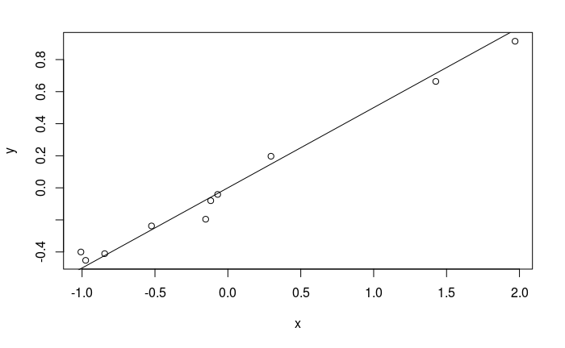

```r
set.seed(1050)
N <- 10
p <- 1
x <- scale(matrix(rnorm(N*p), ncol=p))
b <- c(0.5)
y <- x %*% b + rnorm(N, sd=.1)
plot(x, y)
abline(0,0.5)
```

# 4 Calulate Beta

## 4.1 Using lm function

`lm` 함수를 사용해서 간단하게 $\beta$(coefficients)를 구할 수 있다.

```r
lr_pack <- lm(y ~ .-1, data=data.frame(X=x, y=y))
lr_pack$coefficients
```

```
        X
0.4626264
```

## 4.2 Using batch gradient descent

이제 다음과 같이 batch gradient descent 방법으로 해를 찾을 수 있다.  
해는 `lm`함수를 사용한 결과와 동일하고, 약 200회 전에 수렴하는 것으로 보인다.

```r
bg <- 10  ## 초기값
bg_hist <- c()
lr = 0.05 ## 학습률
for(i in 1:1000) {
    loss <- sum( (y-bg*x)^2 ) / (2*length(y))
    gd <- sum(-x*(y - bg*x)) / length(y)
    bg <- bg - lr*gd
    bg_hist <- c(bg_hist, bg)
}
print(bg)
```

```
[1] 0.4626264
```

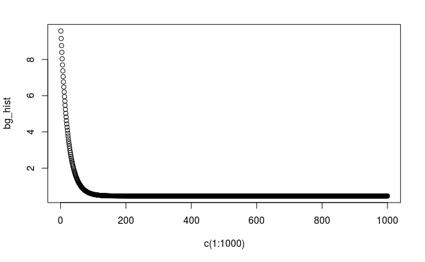

```r
plot(c(1:1000), bg_hist)
```

## 4.3 Using newton method

이제 nethon method로 beta를 계산해 본다.

$f(x)$를 loss function이라 하면, gradient x는 $f'(x)$가 된다.  
결과 beta는 0.438로 나타나고 history를 보면, 특정 값에 수렴하지 않고 0 주위로 일정하며, 중간중간 이상치 들이 발생하는 모습이다.  
무엇이 잘 못 된 것인가??

```r
bn <- 10
bn_hist <- c()
for(i in 1:1000) {
    loss <- sum( (y-bn*x)^2 ) / (2*length(y))
    gd <- sum(-x*(y - bn*x)) / length(y)
    bn <- bn - loss/gd
    bn_hist <- c(bn_hist, bn)
}
print(bn)
```

```
[1] 0.4386885
```

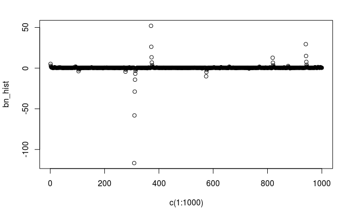

```r
plot(c(1:1000), bn_hist)
```

newton method에서는 f(x)를 0이 되는 점(해)을 찾는 것이고, gradient descent에서는 f(x)가 최소가 되는 점을 찾는 것이다.  
“first question”의 오류는 newton method와 gradient descent의 f(x)를 동일하게 생각했다는 것이다. 다시, g.d는 f(x)가 최소가 되는 점을 찾기 위해 $f'(x)$가 0이 되는 점을 찾는 다. 즉, n.m는 $f'(x)$부터 시작해서 0이 되는 점을 찾는 것인데, $f'(x)$ 에서의 기울기가 필요하므로 $f''(x)$ 값이 필요하다.  
$Loss=f(x)$라고 한다면, n.m에서 $x_{n+1}=x_n - \frac{f'(x)}{f''(x)}$ 이 되는 것이다.  
다시 n.m으로 beta를 찾아보자.

```r
bn2 <- 10
bn2_hist <- c()
for(i in 1:1000) {
    gd <- sum(-x*(y - bn2*x)) / length(y)
    gd2 <- sum(x^2) / length(y)
    bn2 <- bn2 - gd / gd2
    bn2_hist <- c(bn2_hist, bn2)
}
print(bn2)
```

```
[1] 0.4626264
```

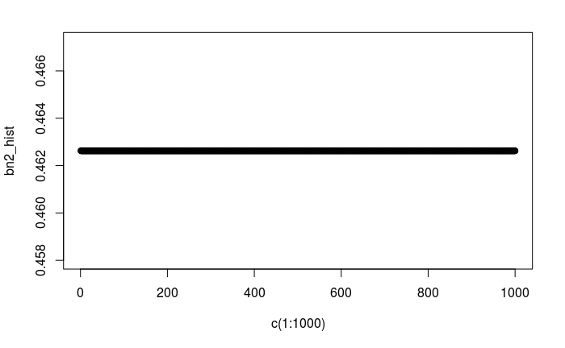

```r
plot(c(1:1000), bn2_hist)
```

beta는 0.4626으로 lm과 g.d 방법과 동일하게 나타났다.  
history graph를 보면, 첫번째 시도 부터 해를 찾았고 계속 동일하게 나타난다.  
사실, mean squared error는 2차 식이기 때문에, $f'(x)$는 1차 식이 된다. 그리고 기울기 $f''(x)$는 상수가 된다.  
즉, $f'(x)$는 0을 지나는 직선이기 때문에, 어떤 점에서 시작을 해도 한번에 0인 점을 찾을 수 있는 것이다.

```r
## loss가 2차 식이기 때문에 미분 값이 1차식이고 그러므로 한방에 해를 찾을 수 있음.
bn2 <- 100
gd <- sum(-x*(y - bn2*x)) / length(y)
gd2 <- sum(x^2) / length(y)
bn2 <- bn2 - gd / gd2
bn2
```

```
[1] 0.4626264
```

## 4.4 What about for the stochastic method??

### 4.4.1 Gradient descent

beta값은 0.4638로 전체(batch)로 학습한 beta값과 유사하게 수렴하는 것으로 나타난다.  
학습 횟수는 약 6000회 이상에서 수렴하는 것으로 보이고, epoch으로는 약 600회이다.  
stochastic 방법이 batch 방법보다 서서히 감소하는 것을 확인할 수 있다.

```r
bg <- 10
bg_hist <- c()
lr = 0.001
for(i in 1:1000) {
    ### epoch마다 shuffling한다.
    #shuffle <- sample(1:10)
    #xs <- x[shuffle]
    #ys <- y[shuffle]
    for(j in 1:length(y)) {
        loss <- (y[j] - bg * x[j])^2  / 2
        gd <- -x[j] * ( y[j] - bg * x[j] )
        bg <- bg - lr*gd
        bg_hist <- c(bg_hist, bg)
    }
}
print(bg)
```

```
[1] 0.4637544
```

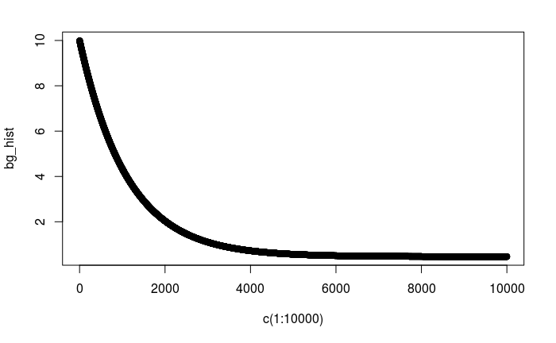

```r
plot(c(1:10000), bg_hist)
```

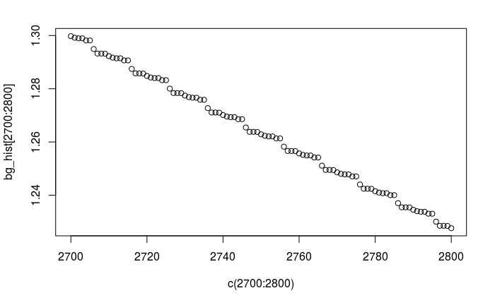

```r
plot(c(2700:2800), bg_hist[2700:2800])
```

### 4.4.2 Newton method

Newton method로 stochastic하게 학습한다면, beta 값은 0.397로 나타난다.  
history를 보면 beta 값이 수렴하는 것이 아니라, 일정한 패턴으로 반복되고 있는 것 으로 보인다.  
위 batch 방법에서 newton method는 한방에 beta해를 찾는다. 즉, stochastic하게 학습할 경우 다음 history와 같이 데이터 하나 하나 계속 beta값이 변하게 될 것이다.  
결론적으로 newton method를 사용하여 stochastic 또는 미니배치로 학습할 경우 데이터가 마지막 데이터에 피팅되기 때문에 올바른 결과를 얻기 어려울 것이다.

```r
bn2 <- 10
bn2_hist <- c()
for(i in 1:10) {
    #shuffle <- sample(1:10)
    #xs <- x[shuffle]
    #ys <- y[shuffle]
    for(j in 1:length(y)) {
        gd <- -x[j] *(y[j] - bn2*x[j])
        gd2 <- sum(x[j]^2)
        bn2 <- bn2 - gd / gd2
        bn2_hist <- c(bn2_hist, bn2)
    }
}
print(bn2)
```

```
[1] 0.3967861
```

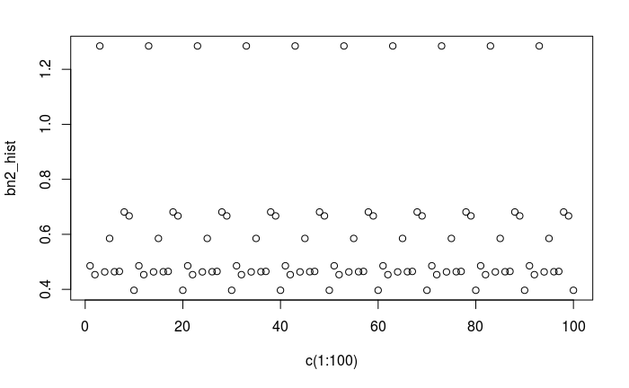

```r
plot(c(1:100), bn2_hist)
```

# 5 Newton method for Multivariate

다 변량일 경우 newton method는 $f''(x)$를 구해야 하기 때문에 해를 구하기가 복잡해진다.
예를 들어 이변량일 경우,
$f(x,y)$에 대하여, $f'(x,y)=df(x,y)=\frac{\partial f}{\partial x}dx + \frac{\partial f}{\partial y}dy$ 로 나타낼 수 있다.
newton method는 $f'(x,y)$가 0이 되는 해가 필요하므로 각 변수에 대한 편미분을 수행한다.
$$\frac {\partial f'}{\partial x} = \frac {\partial^2 f'}{\partial x^2}dx + \frac {\partial^2 f'}{\partial x \partial y}dy$$
$$\frac {\partial f'}{\partial y} = \frac {\partial^2 f'}{\partial y \partial x}dx + \frac {\partial^2 f'}{\partial y^2}dy$$
$$=>$$
$$\left[ \begin{gathered}
\frac {\partial f'}{\partial x} \hfill \\
\frac {\partial f'}{\partial y} \hfill \\
\end{gathered} \right] = \left[ {\begin{array}{*{20}{c}}
{\frac {\partial^2 f'}{\partial x^2}}&{\frac {\partial^2 f'}{\partial x \partial y}} \\
{\frac {\partial^2 f'}{\partial y \partial x}}&{\frac {\partial^2 f'}{\partial y^2}}
\end{array}} \right]\left[ {\begin{array}{*{20}{c}}
{dx} \\
{dy}
\end{array}} \right]$$

즉, 우측식 첫번째 matrix가 Hessian matrix가 된다.  
중간 유도 과정은 너무 복잡하여 생략하고 결과 식을 본다면, 먼저 일변량에서는 $x_{n+1}=x_n - \frac{f'(x)}{f''(x)}$ 이와같이 표현되었다.  
다변량에서는 $f''(x)$가 H가 됨으로, $X_{n+1} = X_n - H^{-1}f'(X_n)$ 이 된다.  
즉, 다변량에서는 Hessian matrix의 역행렬이 필요하게 된다. 그러므로 변수(d)가 많을 수록 H가 $d\times d$로 커지게 됨으로 연산량이 매우 커지게 된다.

# 6 Conclusion

Newton Method를 기계학습관점에서 Gradient Descent와 비교하며 code로 동작 원리를 확인하였다.  
확인한 사실을 요약하면 다음과 같다.

- G.D는 $Loss=f(x)$의 최소가 되는 점을 조금씩 찾아 가는 것이고 N.M은 $f'(x)$가 0이 되는 해를 찾아 가는 것이다.
  - 결국 목적은 같지만, 시작점과 방법에 차이가 있다.
- G.D는 점진적으로 해를 찾아가기 때문에 learning rate라는 설정 파라미터가 필요하고 그에 따라 수렴속도의 차이를 가진다.  
  N.M은 설정 파라미터가 필요 없고 빠른 수렴속도를 가진다.
- G.D는 Mini-batch를 사용하여 학습 효율을 높일 수 있지만, N.M은 마지막 데이터에 피팅이 되므로 사용하기 어렵다.
- 다변량의 경우 G.D는 변수 만큼의 편미분 계산이 필요하지만, N.M은 변수의 제곱만큼 계산이 필요하므로 그리고 역함수를 계산해야 하므로 변수가 많이 질 수록 연산량이 매우 높아지게 된다.

기존 빅데이터-딥러닝에서 주로 G.D가 사용되는 것이 이러한 N.M의 약점 때문이라고 생각된다.